# 📊 Retail Sales Analysis

## **Objective**

```python
import pandas as pd
import matplotlib.pyplot as plt
import seaborn as sns
```

```python
# Load datasets
order_details = pd.read_excel("C:\MIne\Order_Details.xlsx")
products = pd.read_excel("C:\MIne\Products.xlsx")
property_info = pd.read_excel("C:\MIne\Property_Info.xlsx")

print(order_details.head(3))
print(products.head(3))
print(property_info.head(3))
```

```
   OrderID            OrderDate  PropertyID  ProductID  Quantity
0        1  2015-01-01 00:00:00          17         41         1
1        2  2015-01-01 00:00:00          15         54         2
2        3  2015-01-01 00:00:00           5         71         2
   ProductID  ProductName ProductCategory  Price
0          1  Large Towel    Housekeeping      9
1          2   Hand Towel    Housekeeping      5
2          3    Washcloth    Housekeeping      3
   Prop ID PropertyCity PropertyState
0        1     New York      New York
1        2   Cincinnati          Ohio
2        3     Portland        Oregon
```

```python
# Rename inconsistent column
property_info.rename(columns={"Prop ID": "PropertyID"}, inplace=True)
print(property_info.head(3))

# Merge datasets
df = order_details.merge(products, on="ProductID", how="left").merge(property_info, on="PropertyID", how="left")
df.head()
```

```
   PropertyID PropertyCity PropertyState
0           1     New York      New York
1           2   Cincinnati          Ohio
2           3     Portland        Oregon
```

|  | OrderID | OrderDate | PropertyID | ProductID | Quantity | ProductName | ProductCategory | Price | PropertyCity | PropertyState |
| --- | --- | --- | --- | --- | --- | --- | --- | --- | --- | --- |
| 0 | 1 | 2015-01-01 00:00:00 | 17 | 41 | 1 | Office Chair | Furnishings | 85 | Las Vegas | Nevada |
| 1 | 2 | 2015-01-01 00:00:00 | 15 | 54 | 2 | Chest of Drawers | Furnishings | 150 | Chicago | Illinois |
| 2 | 3 | 2015-01-01 00:00:00 | 5 | 71 | 2 | Hammer | Maintenance | 17 | Kansas City | Missouri |
| 3 | 4 | 2015-01-01 00:00:00 | 19 | 3 | 2 | Washcloth | Housekeeping | 3 | Los Angeles | California |
| 4 | 5 | 2015-01-01 00:00:00 | 12 | 45 | 3 | Computer Desk | Furnishings | 102 | Dallas | Texas |

```python
df.columns
```

```
Index(['OrderID', 'OrderDate', 'PropertyID', 'ProductID', 'Quantity',
       'ProductName', 'ProductCategory', 'Price', 'PropertyCity',
       'PropertyState'],
      dtype='object')
```

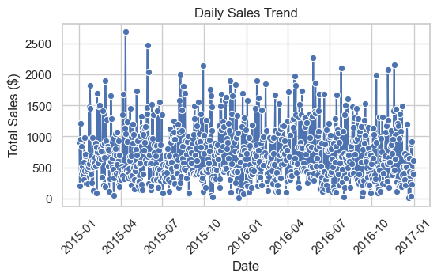

```python
# Convert OrderDate to datetime
df["OrderDate"] = pd.to_datetime(df["OrderDate"])

# Create Total Sales column
df["TotalSales"] = df["Quantity"] * df["Price"]

# Set plot style
sns.set_theme(style="whitegrid")

# Sales Trend Over Time
df_sales_trend = df.groupby("OrderDate")["TotalSales"].sum().reset_index()
plt.figure(figsize=(6, 3))
sns.lineplot(data=df_sales_trend, x="OrderDate", y="TotalSales", marker="o", color="b")
plt.title("Daily Sales Trend")
plt.xlabel("Date")
plt.ylabel("Total Sales ($)")
plt.xticks(rotation=45)
plt.show()
```

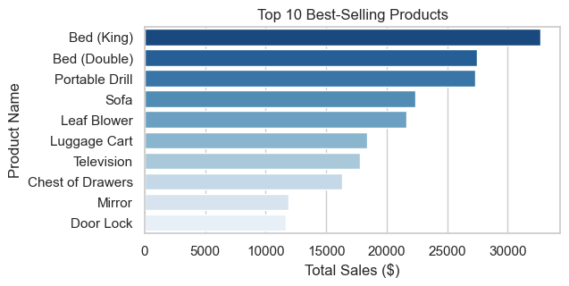

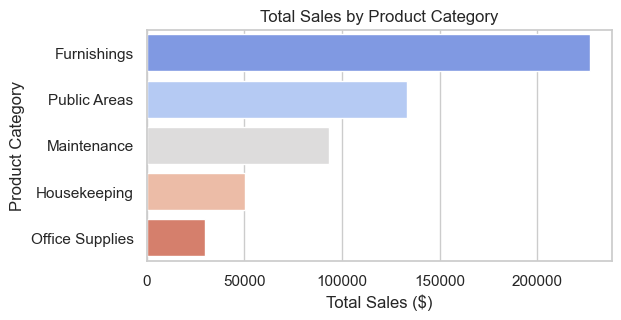

```python
# Top 10 Best-Selling Products
top_products = df.groupby("ProductName")["TotalSales"].sum().sort_values(ascending=False).head(10)
plt.figure(figsize=(6, 3))
sns.barplot(x=top_products.values, y=top_products.index, palette="Blues_r")
plt.title("Top 10 Best-Selling Products")
plt.xlabel("Total Sales ($)")
plt.ylabel("Product Name")
plt.show()

# Total Sales by Product Category
top_categories = df.groupby("ProductCategory")["TotalSales"].sum().sort_values(ascending=False)
plt.figure(figsize=(6, 3))
sns.barplot(x=top_categories.values, y=top_categories.index, palette="coolwarm")
plt.title("Total Sales by Product Category")
plt.xlabel("Total Sales ($)")
plt.ylabel("Product Category")
plt.show()
```

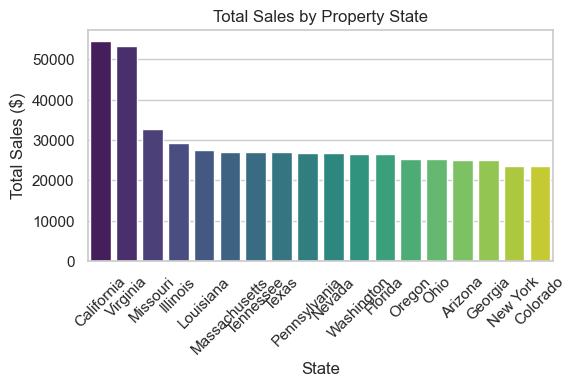

```python
# Sales by Property State
state_sales = df.groupby("PropertyState")["TotalSales"].sum().sort_values(ascending=False)
plt.figure(figsize=(6, 3))
sns.barplot(x=state_sales.index, y=state_sales.values, palette="viridis")
plt.title("Total Sales by Property State")
plt.xlabel("State")
plt.ylabel("Total Sales ($)")
plt.xticks(rotation=45)
plt.show()
```

## **Conclusion**

The **Retail Sales Analysis** revealed key insights into **sales performance, product trends, and regional contributions**:

✅ **Sales Trends:**

- Sales fluctuate over time, with notable **peaks and dips** indicating potential seasonal trends.
- Identifying these patterns can help with better forecasting and inventory planning.

✅ **Regional Sales Performance:**

- Some **states/cities** contribute more to total sales than others.
- This highlights the importance of **regional marketing strategies** and targeted sales efforts.

✅ **Opportunities for Growth:**

- There are untapped opportunities in **underperforming regions** that can be improved with better marketing.
- **Customer segmentation** can help in personalizing sales strategies to maximize profitability.

## **Recommendations**

📌 **1. Optimize Inventory Management**

- Focus on maintaining **adequate stock levels** for high-demand products.
- Reduce excess inventory of **low-performing products** to minimize holding costs.

📌 **2. Strengthen Marketing Strategies**

- Invest more in advertising for **top-selling products and categories** to maximize sales.
- Implement **region-specific promotions** for low-performing states to increase customer engagement.

📌 **3. Implement Dynamic Pricing**

- Use demand forecasting to adjust **prices dynamically** based on customer demand and seasonal trends.
- Offer discounts and bundles on **slow-moving products** to clear inventory.

📌 **4. Leverage Customer Segmentation**

- Perform **RFM Analysis** to segment customers into:
  - **High-value customers** (frequent buyers) → Provide loyalty rewards.
  - **Churn-risk customers** (haven’t purchased in a while) → Offer targeted discounts.
- Personalize marketing campaigns based on customer purchasing behavior.

📌 **5. Expand High-Performing Regions**

- Allocate **more sales and distribution resources** to high-revenue regions.
- Identify why some regions are underperforming and improve marketing efforts there.

📌 **6. Enhance Sales Forecasting & Reporting**

- Use **predictive analytics** to anticipate future sales trends.
- Continuously update **Power BI dashboards** with real-time data for better decision-making.